# Downloading R and RStudio

Nick Sumpter (Edited by Eddie-Williams Owiredu & Guy Twa)

2023-08-21

## Today’s Lab

Our goal for these labs is to teach you how to use the R programming language for common statistical analyses. We hope that by the end of this course you will feel comfortable using R to run all of your statistical analyses during your PhD.

Today’s lab will be very simple: we want you to download the latest version of R (version 4.3.1) and RStudio (version 2023.06.1+524). We will then spend some time getting you familiar with the RStudio interface.

## Downloading R

Go to the following website: https://mirrors.nics.utk.edu/cran/

You will see the following at the top of the page.

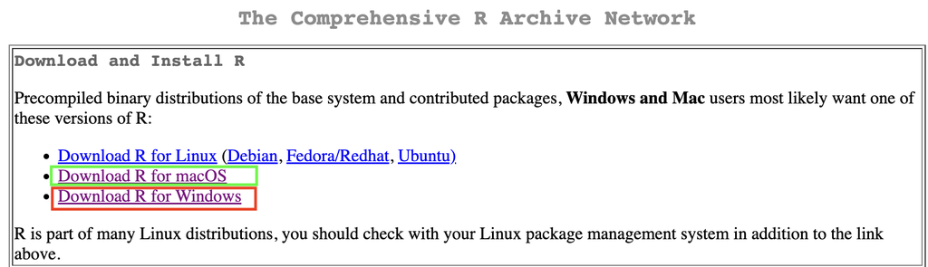

Click on the appropriate link depending on whether you have a Windows, Mac, or Linux computer.

### Windows

Clicking on the “Download R for Windows” link will take you to the following page. You then need to click either “base” or “install R for the first time”, both will take you to the same page.

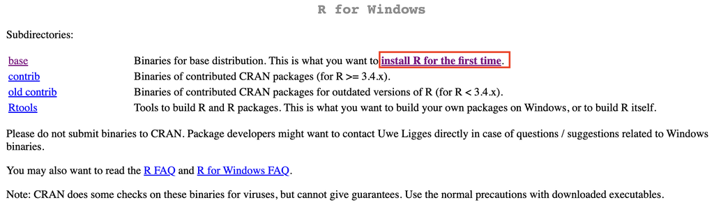

The following page will then open, where you need to click the big “Download R 4.3.1 for Windows” link.

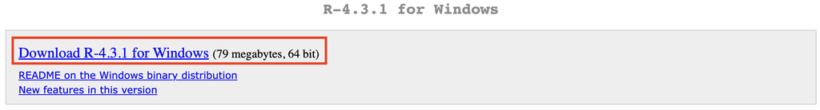

This will download a file called “R-4.3.1-win.exe”. Find this file in your downloads and run it.

Allow the app to access your files, then select a language from the drop-down menu, then simply click the “Next >” button repeatedly, then the “Finish” button when it shows up.

You now have R installed on your computer, which can technically be used as is to write and run R scripts, but we will use RStudio which is essentially a pretty interface for R with some extra functionality.

### Mac

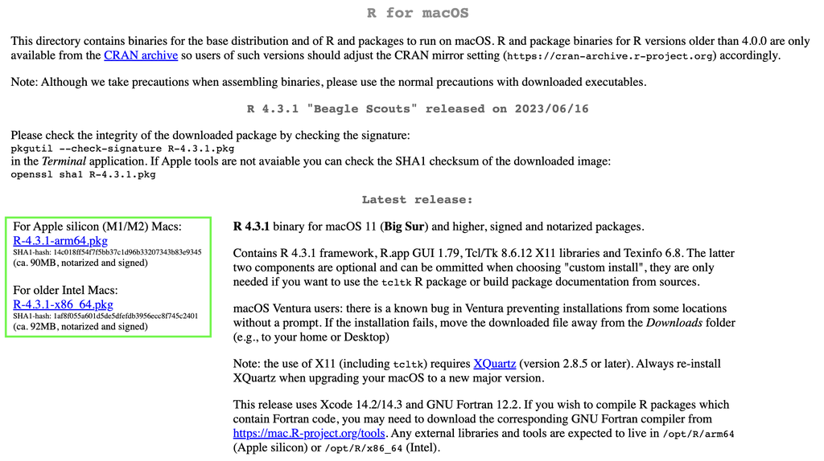

Now, you will need to run through the installer, keeping all of the default options selected. If you are using a shared computer you may wish to select a different directory for installing R. After clicking through all default options, R should install correctly onto your device. You may then move the .pkg file to your trash.

## Downloading RStudio

Go to the following website: https://www.rstudio.com/products/rstudio/download/#download

You should see a big link at the top for the appropriate installer for your device, and if not, there are a list of links down below.

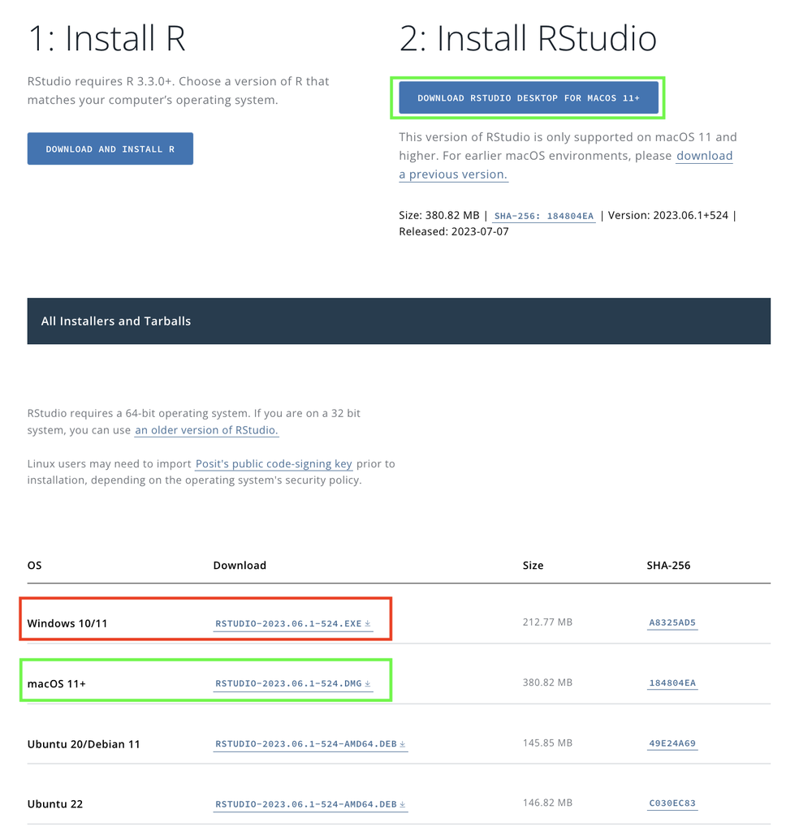

Click on the appropriate link depending on whether you have a Windows, a Mac, or a Linux computer.

### Windows

Clicking on the “DOWNLOAD RSTUDIO FOR WINDOWS” link, or the “RSTUDIO-2023.06.1-524.EXE” link next to “Windows 10/11” will download the RStudio installer.

Find the “RSTUDIO-2023.06.1-524.EXE” file in your downloads and run it.

Allow the app to access your files, then simply click the “Next >” button repeatedly, then the “Install” button when it shows up.

You now have RStudio installed on your computer, which you should go ahead and open up.

### Mac

Clicking on the “DOWNLOAD RSTUDIO DESKTOP FOR MACOS 11+” link, or the “RSTUDIO-2023.06.1-524.DMG” link next to “macOS 11+” will download RStudio. You will then need to run the downloaded .dmg file and you will see something similar to the following pop up on your screen (note this was for an older version of RStudio):

[figure not shown]

Now, you will need to drag and drop RStudio into your Applications folder. RStudio will now be installed on your computer!

## Getting to know RStudio

Great work, you now have R and RStudio downloaded onto your computer and you are ready to start coding.

The first step is to just open RStudio. If you are on Windows 10/11, simply click the Windows start menu and type in “rstudio” then press “Enter”. If you are on a Mac, you can click on the small magnifying glass in the top right corner of your screen then type “rstudio” then press “Return”.

Now you will see the default RStudio interface.

[figure not shown]

This may feel slightly overwhelming to look at, but don’t worry! We will break down the important components for you and you can just ignore everything else. For today, we are just going to look at where things are and what they are for. Tomorrow we will practice actually using RStudio.

### The Console

The first panel of the RStudio interface that you should see is the Console.

[figure not shown]

This can be thought of as where R reads the code and runs the computation.

### The Environment

Now for the Environment panel.

[figure not shown]

This panel is where you will see everything that you have loaded into R. This includes datasets, functions and other objects.

### The Files tab

In the bottom right panel, there are several tabs available, the first of which is the Files tab.

[figure not shown]

This tab shows your current directory, and allows you to navigate to files, open/read files into R, delete files and much more.

### The Plots tab

Next to the Files tab is the Plots tab.

[figure not shown]

This tab is where your plots will appear when you generate them in the Console.

### The Help tab

Ignoring the Packages tab for now, the Help tab is also in the bottom right panel.

[figure not shown]

This tab may well be the most useful tab when starting out. It allows you to look up any function and see its documentation by typing in the search box.

### The Header

Now, you will see a series of buttons available at the top of your screen (starting with a symbol for a piece of paper with a green plus).

[figure not shown]

This is where you can find shortcuts for opening new script files, saving files, and more.

### Global Options

Finally, you can also see several menus at the top left or right (for Windows or Mac respectively) of your screen. Though there is a lot of functionality in these menus, perhaps the best menu is the Tools menu. This is because it contains “Global Options”. Click on this and it will bring up a new menu.

[figure not shown]

In this menu, make sure to change your Workspace to not restore .RData at startup and to never save workspace as .RData on exit. Changing these two options will make it so RStudio doesn’t try to save your session and restore it upon restarting RStudio, which may be useful for some people but will cause RStudio to start slower and is generally not a good habit to get into. In general, it is always best to deliberately save your code and data as needed, rather than relying on RStudio to do it for you.

[figure not shown]

Next, click on the “Code” tab on the left, and ensure that the “Soft-wrap R source files” box is ticked, which will make it easier to view and edit your code without having it go off the edge of your window.

[figure not shown]

Finally, click on the Appearance tab. Here, you can modify the font, zoom, font size and most importantly the editor theme. I personally struggle to stare at the bright white default RStudio interface for hours each day. Instead, I would highly recommend one of the darker themes. My personal favorites are “Solarized Dark” and “Solarized Light”, but go ahead and try out a few to see which you prefer.

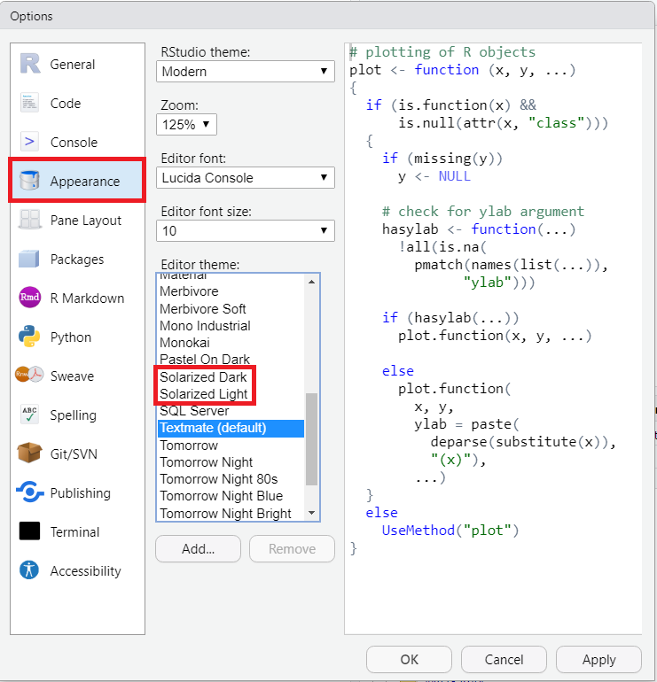

## Wrapping up

So, today, many of you have started into the world of programming with R in RStudio. This will prove itself to be one of the most powerful tools for all statistical analyses you wish to perform. It also enables you to fully customize publication quality figures along with high quality reports for sharing with collaborators. I would recommend you spend some time familiarizing yourself with the RStudio interface before next class, as you will be spending a fair amount of time using it throughout the remainder of this course.